# GAM_PISA

Hugo Cesar Octavio del Sueldo

11/7/2020

# Caso Practico 03: Pruebas PISA

The data set has been constructed using average Science scores by country from the Programme for International Student Assessment (PISA) 2006, along with GNI per capita (Purchasing Power Parity, 2005 dollars), Educational Index, Health Index, and Human Development Index from UN data. The key variables are as follows:

El conjunto de datos se ha construido utilizando la puntuación media en Ciencias por país del Programa para la Evaluación Internacional de Estudiantes (PISA) 2006, junto con el GNI per cápita (paridad del poder adquisitivo, dólares de 2005), el índice educativo, el índice de salud y el índice de desarrollo humano de la ONU (HDI).

## Diccionario de variables:

- Overall Science Score (average score for 15 year olds)
- Interest in science
- Support for scientific inquiry
- Income Index
- Health Index
- Education Index
- Human Development Index (composed of the Income index, Health Index, and Education Index)

El objetivo es modelizar la relación entre la puntuación media (OSS) y el resto de variables, utilizando modelos de splines y GAM. Se debe realizar CV cuando se pueda.

Los datos se encuentran en el fichero `pisasci2006.csv`

## Cargamos los datos

```r
head(pisa)
```

```
## # A tibble: 6 x 11
##   Country Overall Issues Explain Evidence Interest Support Income Health    Edu
##   <chr>     <dbl>  <dbl>   <dbl>    <dbl>    <dbl>   <dbl>  <dbl>  <dbl>  <dbl>
## 1 Albania      NA     NA      NA       NA       NA      NA  0.599  0.886  0.716
## 2 Argent…     391    395     386      385      567     506  0.678  0.868  0.786
## 3 Austra…     527    535     520      531      465     487  0.826  0.965  0.978
## 4 Austria     511    505     516      505      507     515  0.835  0.944  0.824
## 5 Azerba…     382    353     412      344      612     542  0.566  0.78  NA
## 6 Belgium     510    515     503      516      503     492  0.831  0.935  0.868
## # … with 1 more variable: HDI <dbl>
```

```r
tail(pisa)
```

```
## # A tibble: 6 x 11
##   Country Overall Issues Explain Evidence Interest Support Income Health   Edu
##   <chr>     <dbl>  <dbl>   <dbl>    <dbl>    <dbl>   <dbl>  <dbl>  <dbl> <dbl>
## 1 Tunisia     386    384     383      382      590     534  0.597  0.846 0.608
## 2 Turkey      424    427     423      417      540     563  0.679  0.828 0.562
## 3 United…      NA     NA      NA       NA       NA      NA  0.909  0.878 0.686
## 4 United…     515    514     517      514      464     470  0.833  0.934 0.798
## 5 United…     489    492     486      489      480     490  0.872  0.911 0.93
## 6 Uruguay     428    429     423      429      567     510  0.658  0.884 0.74
## # … with 1 more variable: HDI <dbl>
```

## Limpieza del dataset

### Selección de variables

Las variables clave son las siguientes:

- Overall Science Score (average score for 15 year olds)
- Interest in science
- Support for scientific inquiry
- Income Index
- Health Index
- Education Index
- Human Development Index (composed of the Income index, Health Index, and Education Index)

```r
pisa %<>% select(Country, Overall, Interest, Support, Income, Health, Edu, HDI)
```

### Renombrar columnas

Comenzaremos el data cleaning cambiando los nombres de las columnas a minusculas siguiendo con las buenas practicas de codigo

```r
pisa %<>% clean_names()   # # clean_names() nos modifica aquellos nombres que tienen simbolos que estan reservados para calculo o como palabras reservadas del codigo.
colnames(pisa)
```

```
## [1] "country"  "overall"  "interest" "support"  "income"   "health"   "edu"
## [8] "hdi"
```

Una vez tenemos los nombres de las variables en el formato correcto, pasamos al tratamiento de duplicados y de nulos

### Data cleaning

Vamos a chequear los duplicados y los nulos en el dataset.

```r
# Remove duplicate rows of the dataframe
pisa %<>% distinct(country,.keep_all= TRUE)



summarise_all(pisa, funs(sum(is.na(.)))) #cuentame los valores nulos en el dataset
```

```
## # A tibble: 1 x 8
##   country overall interest support income health   edu   hdi
##     <int>   <int>    <int>   <int>  <int>  <int> <int> <int>
## 1       0       8        8       8      4      4     6     6
```

En esta ocasión tenemos un dataset pequeño con bastantes nulos, por lo que si eliminamos estos valores con `drop_na()` perderemos mucha informacion,por ello cambiaremos los nulos por un estadistico como la media.

```r
pisa <- na_mean(pisa) # Como existen muchos valores nulos los sustituimos por la media con la funcion na_mean() de la libreria imputeTS
```

Por lo tanto, ya tenemos nuestro dataset `pisa` limpio para poder explorarlo

## Exploratory Data Analysis

Vamos a realizar un breve chequeo de la distribucion y comportamiento de las variables. Voy a utilizar las funciones skim y chart.Correlation aprendidas en clases anteriores para conocer los principales estadisticos, histogramas, densidades, correlaciones, etc.

### Estadisticos relevantes

```r
skim(pisa)
```

Data summary

| Name | pisa |
| --- | --- |
| Number of rows | 65 |
| Number of columns | 8 |
| _______________________ |  |
| Column type frequency: |  |
| character | 1 |
| numeric | 7 |
| ________________________ |  |
| Group variables | None |

**Variable type: character**

| skim_variable | n_missing | complete_rate | min | max | empty | n_unique | whitespace |
| --- | --- | --- | --- | --- | --- | --- | --- |
| country | 0 | 1 | 4 | 24 | 0 | 65 | 0 |

**Variable type: numeric**

| skim_variable | n_missing | complete_rate | mean | sd | p0 | p25 | p50 | p75 | p100 | hist |
| --- | --- | --- | --- | --- | --- | --- | --- | --- | --- | --- |
| overall | 0 | 1 | 473.14 | 51.06 | 322.00 | 436.00 | 487.00 | 511.00 | 563.00 | ▁▂▂▇▃ |
| interest | 0 | 1 | 528.16 | 46.62 | 448.00 | 503.00 | 528.16 | 549.00 | 644.00 | ▆▇▇▃▂ |
| support | 0 | 1 | 512.18 | 24.40 | 447.00 | 497.00 | 512.18 | 527.00 | 569.00 | ▂▃▇▅▂ |
| income | 0 | 1 | 0.74 | 0.11 | 0.41 | 0.66 | 0.74 | 0.83 | 0.94 | ▁▂▆▇▅ |
| health | 0 | 1 | 0.89 | 0.06 | 0.72 | 0.84 | 0.89 | 0.94 | 0.99 | ▂▂▇▇▇ |
| edu | 0 | 1 | 0.80 | 0.11 | 0.54 | 0.74 | 0.80 | 0.87 | 0.99 | ▂▃▇▇▅ |
| hdi | 0 | 1 | 0.81 | 0.08 | 0.58 | 0.75 | 0.81 | 0.87 | 0.94 | ▁▃▆▇▆ |

### Correlaciones

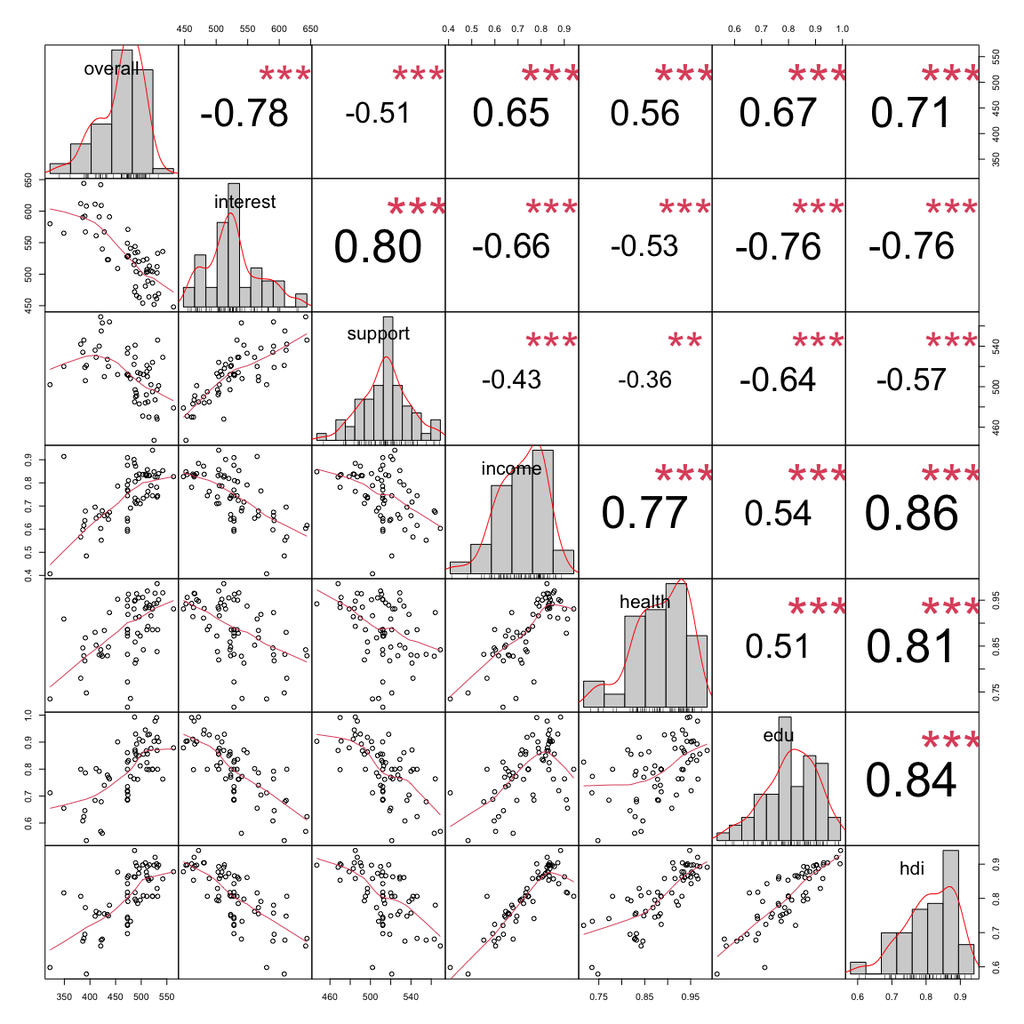

```r
chart.Correlation(pisa %>%
               select_at(vars(-country)),
               histogram = TRUE, pch = 19)  #sacamos las variables categoricas de nuestra matriz de correlaciones
```

Vemos como existen ciertas correlaciones, como la del hdi con la educacion, health o income.

## Splines suavizados

### Teoría

- Son las splines de regresion, que se crean especificando un conjunto de nudos, produciendo una secuencia de funciones de base, y luego usando mínimos cuadrados para estimar los coeficientes de spline.
- Suavizar splines es un enfoque diferente para crear una spline. Hay que encontrar una función que haga que el RSS sea razonablemente pequeño, pero que también sea fluido.
- Una forma de hacerlo es utilizar un parámetro de ajuste lambda que penaliza la variabilidad en la función:
- Si lambda = 0, el término de penalización no tiene ningún efecto, y la función estará turbia e interpolará cada valor.
- Cuando lamba = infinito, la función será perfectamente suave, una línea recta (en realidad, una línea lineal de mínimos cuadrados).
- Recurrimos a la validación cruzada para suavizar splines. Resulta que realmente podemos calcular LOOCV de manera muy eficiente para suavizar splines, splines de regresión y otras funciones básicas arbitrarias.

### Practica

Como comentamos anteriormente, a traves de cross_validation vamos a conseguir los grados de libertad optimos de cada variable.

`This is based on a leave one out crossvalidation approach. The strategy is to remove one data point at a time, fit a smoother to the remaining data, and then fit of the smoother against the entire data set. The goal is to pick the lambda(j) that minimizes the average error across all n validations.`

```r
attach(pisa)
fit_interest <- smooth.spline(x = interest, y = overall, cv = TRUE) # fit de la variable interest
fit_interest$df
```

```
## [1] 4.750171
```

```r
fit_support <- smooth.spline(x = support, y = overall, cv = TRUE) # fit de la variable support
fit_support$df
```

```
## [1] 2.001243
```

```r
fit_income <- smooth.spline(x = income, y = overall, cv = TRUE) # fit de la variable income
fit_income$df
```

```
## [1] 4.244952
```

```r
fit_health <- smooth.spline(x = health, y = overall, cv = TRUE) # fit de la variable health
fit_health$df
```

```
## [1] 2.002844
```

```r
fit_edu <- smooth.spline(x = edu, y = overall, cv = TRUE) # fit de la variable health
fit_edu$df
```

```
## [1] 2.002385
```

```r
fit_hdi <- smooth.spline(x = hdi, y = overall, cv = TRUE) # fit de la variable hdi
fit_hdi$df
```

```
## [1] 8.603228
```

Una vez tenemos los resultados de los grados de libertad ideales para cada variable por CV:

- Interest: 4.750171
- Support: 2.001243
- Income: 4.244952
- Health: 2.002844
- Edu: 2.002385
- HDI: 8.603228

Comprobaremos la diferencia de haber obtenido los grados de libertad por Cross-Validation a haberlos introducido manualmente al azar:

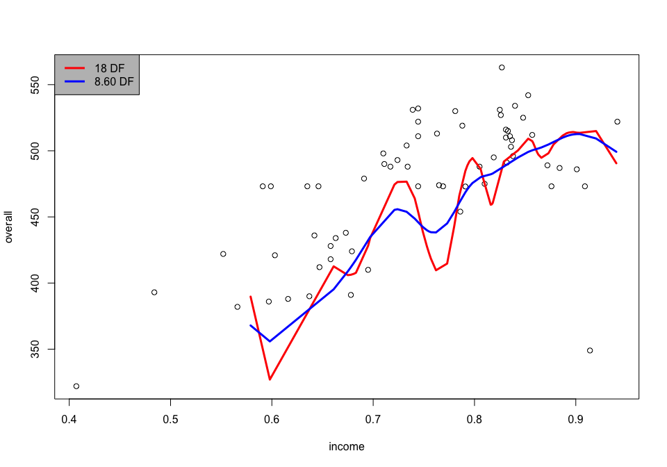

```r
# Para nuestro ejemplo elegimos la variable hdi:
# Primero, generamos un smooth.spline con 18 grados de libertad (este número es al azar)
fitdf18_hdi <- smooth.spline(x = hdi, y = overall, df = 18)
  # Ploteamos ambos modelos para comparar
plot(income, overall, col = 'black')
  lines(fitdf18_hdi, col = 'red', lwd = 3)   # Plot del modelo con 18 grados de libertad
  lines(fit_hdi, col = 'blue', lwd = 3)            # Plot del modelo con los grados de libertad por CV
  legend('topleft', legend = c('18 DF', '8.60 DF'),   # Parametros de la leyenda
       col = c('red', 'blue'), lty = 1, lwd = 3, cex = 1, bg = 'grey')
```

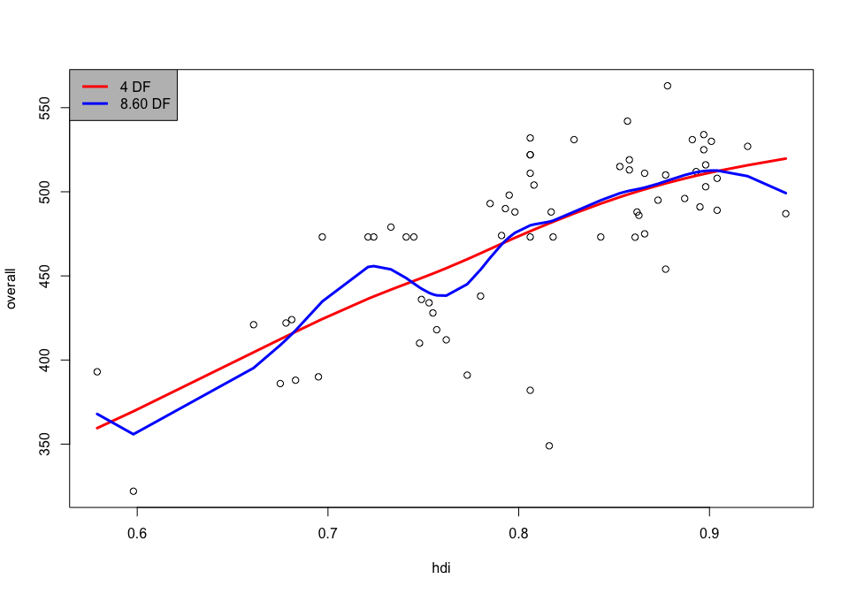

```r
fitdf4_hdi <- smooth.spline(x = hdi, y = overall, df = 4)
  # Ploteamos ambos modelos para comparar
plot(hdi, overall, col = 'black')
  lines(fitdf4_hdi, col = 'red', lwd = 3)   # Plot del modelo con 4 grados de libertad
  lines(fit_hdi, col = 'blue', lwd = 3)            # Plot del modelo con los grados de libertad por CV
  legend('topleft', legend = c('4 DF', '8.60 DF'),   # Parámetros de la leyenda
       col = c('red', 'blue'), lty = 1, lwd = 3, cex = 1, bg = 'grey')
```

## Modelos aditivos generalizados, GAM

### Teoria

- Los splines se explican desde la perspectiva de adaptar un modelo a la respuesta Y con un único predictor X.
- Exploramos el problema de la flexibilidad prediciendo Y sobre la base de varios predictores. Esta es nuevamente una extensión del modelo lineal simple.
- Los modelos GAM proporcionan un marco general para extender el modelo lineal al permitir funciones no lineales de cada variable, mientras se mantiene la capacidad de adición.

### Practica

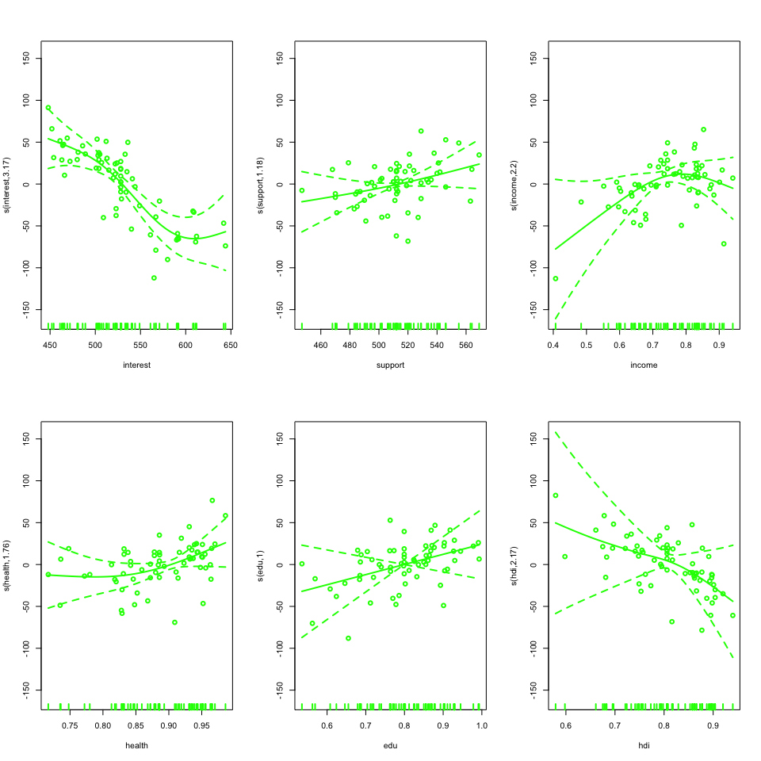

```r
modelogam1 <- gam(overall ~ s(interest, k = 4.750171) + s(support, k = 2.001243) + s(income, k = 4.244952) + s(health, k = 2.002844) + s(edu, k = 2.002385) + s(hdi, k = 8.603228), data = pisa)
par(mfrow = c(2, 3))
plot(modelogam1, se = TRUE, col = 'green', residuals = TRUE, pch = 1, lwd = 2)
```

```r
modelogam2 <- gam(overall ~ interest + support + s(income, k = 4.244952) + health + s(edu, k = 2.002385) + s(hdi, k = 8.603228), data = pisa)
modelogam3 <- gam(overall ~ s(interest, k = 4.750171) + support + s(income, k = 4.244952) + health + s(edu, k = 2.002385) + s(hdi, k = 8.603228), data = pisa)

anova(modelogam1, modelogam2, modelogam3, test = 'F')
```

```
## Analysis of Deviance Table
##
## Model 1: overall ~ s(interest, k = 4.750171) + s(support, k = 2.001243) +
##     s(income, k = 4.244952) + s(health, k = 2.002844) + s(edu,
##     k = 2.002385) + s(hdi, k = 8.603228)
## Model 2: overall ~ interest + support + s(income, k = 4.244952) + health +
##     s(edu, k = 2.002385) + s(hdi, k = 8.603228)
## Model 3: overall ~ s(interest, k = 4.750171) + support + s(income, k = 4.244952) +
##     health + s(edu, k = 2.002385) + s(hdi, k = 8.603228)
##   Resid. Df Resid. Dev       Df Deviance      F  Pr(>F)
## 1    50.816      35096
## 2    51.775      39551 -0.95907  -4455.4 6.9517 0.01191 *
## 3    52.994      37398 -1.21865   2153.6
## ---
## Signif. codes:  0 '***' 0.001 '**' 0.01 '*' 0.05 '.' 0.1 ' ' 1
```

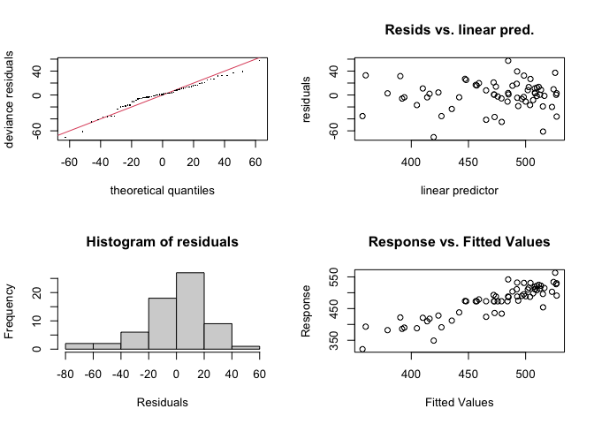

```
##
## Method: GCV   Optimizer: magic
## Smoothing parameter selection converged after 13 iterations.
## The RMS GCV score gradient at convergence was 0.0001521708 .
## The Hessian was positive definite.
## Model rank =  22 / 22
##
## Basis dimension (k) checking results. Low p-value (k-index<1) may
## indicate that k is too low, especially if edf is close to k'.
##
##               k'  edf k-index p-value
## s(interest) 4.00 3.17    0.99   0.445
## s(support)  2.00 1.18    1.21   0.950
## s(income)   3.00 2.20    1.03   0.530
## s(health)   2.00 1.76    0.74   0.005 **
## s(edu)      2.00 1.00    1.09   0.720
## s(hdi)      8.00 2.17    1.13   0.775
## ---
## Signif. codes:  0 '***' 0.001 '**' 0.01 '*' 0.05 '.' 0.1 ' ' 1
```

```r
# Checking de los modelos
gam.check(modelogam1)  #el modelo con el primer gam
```

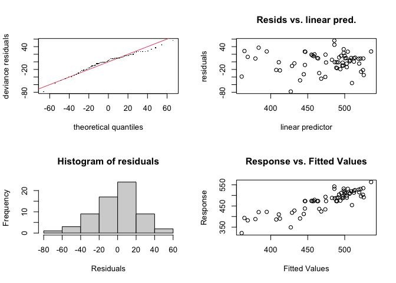

```
##
## Method: GCV   Optimizer: magic
## Smoothing parameter selection converged after 13 iterations.
## The RMS GCV score gradient at convergence was 0.002495187 .
## The Hessian was positive definite.
## Model rank =  17 / 17
##
## Basis dimension (k) checking results. Low p-value (k-index<1) may
## indicate that k is too low, especially if edf is close to k'.
##
##             k'  edf k-index p-value
## s(income) 3.00 2.50    0.98    0.46
## s(edu)    2.00 1.83    1.10    0.81
## s(hdi)    8.00 3.60    1.16    0.86
```

```r
gam.check(modelogam2)  #el segundo modelo con las variables interest, support y health como lineales.
```

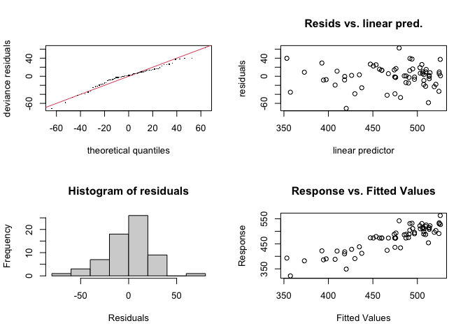

```
##
## Method: GCV   Optimizer: magic
## Smoothing parameter selection converged after 18 iterations.
## The RMS GCV score gradient at convergence was 3.123036e-05 .
## The Hessian was positive definite.
## Model rank =  20 / 20
##
## Basis dimension (k) checking results. Low p-value (k-index<1) may
## indicate that k is too low, especially if edf is close to k'.
##
##               k'  edf k-index p-value
## s(interest) 4.00 3.19    0.98    0.38
## s(income)   3.00 2.56    1.06    0.65
## s(edu)      2.00 1.28    1.09    0.72
## s(hdi)      8.00 1.00    1.08    0.69
```

```r
gam.check(modelogam3)  #tercer modelo gam dejando interest como no lineal
```

```r
summary(modelogam2)
```

```
##
## Family: gaussian
## Link function: identity
##
## Formula:
## overall ~ interest + support + s(income, k = 4.244952) + health +
##     s(edu, k = 2.002385) + s(hdi, k = 8.603228)
##
## Parametric coefficients:
##             Estimate Std. Error t value Pr(>|t|)
## (Intercept) 562.7008   141.4804   3.977 0.000212 ***
## interest     -0.7287     0.1712  -4.257 8.48e-05 ***
## support       0.4016     0.2551   1.575 0.121276
## health      101.1546   117.8017   0.859 0.394376
## ---
## Signif. codes:  0 '***' 0.001 '**' 0.01 '*' 0.05 '.' 0.1 ' ' 1
##
## Approximate significance of smooth terms:
##             edf Ref.df     F p-value
## s(income) 2.500  2.765 2.784  0.0343 *
## s(edu)    1.827  1.933 1.225  0.2390
## s(hdi)    3.603  4.527 0.994  0.3937
## ---
## Signif. codes:  0 '***' 0.001 '**' 0.01 '*' 0.05 '.' 0.1 ' ' 1
##
## R-sq.(adj) =  0.714   Deviance explained = 76.3%
## GCV = 912.78  Scale est. = 745.26    n = 65
```

Por otro lado, los smooth terms son es solo significativa la variable ingresos por lo tanto, deberiamos realizar la regularizacion por el modelo lasso y elastic net para corroborar si es conveniente o no, eliminar esas variables con el fin de buscar el modelo mas significativo para predecir los valores de la variable overall